# Actividad Módulo 28: Introducción a la Clasificación

1. Importación de un modelo de datos de RRHH (general_data.csv)
2. EDA Completo siguiendo los modelos anteriores
3. Feature Engineering - Estandarización, eliminación de columnas innecesarias o que no aportan al modelo, creación de nuevas columnas
4. Aplicación del modelo de regresión logística a la variable Attrition
5. Entrenamiento, evaluación y predicción de resultados del modelo
6. Análisis de sensibilidad e importancia de variables
7. Visualización de resultados del modelo de clasificación
8. Matríz de confusión y medidas del modelo

Descripción de las columnas del datset:

- Attrition - *Variable dependiente*, indica si el empleado salió o no
- BuisnessTravel - Definiciones de la frecuencia de viaje
- Department - Unidad de negocio
- DistanceFromHome - Distancia en millas de su casa
- Education - Nivel Educacional (#)
- EducationField - Campo de educación
- Employee Count - 1
- Gender - Masculino/Femenino
- JobLevel - Nivel de trabajo
- JobRole - Cargo
- MaritalStatus - Estado civil
- MonthlyIncome - Ingreso mensual
- NumCompaniesWorked - No. de empresas en las que trabajó antes
- Over18 - Si tiene más de 18 años
- PercentSalaryHike - El último alza de salario
- StandardHours - Cuántas horas estándar (#)
- StockOptionLevel - Nivel de entrega de ESOP (#)
- TotalWorkingYears - # de años trabajados en la empresa
- TrainintTimesLastYear - Número de capacitaciones que tomó el año anterior
- YearsAtCompany - Años en la empresa (#)
- YearsSinceLastPromotion - Alos desde la última promoción
- YearsWithCurrManager - Años con su manager actual
- La idea del modelo es predecir si un empleado se va a ir de la empresa o no (Attrition)

```python
import pandas as pd
import numpy as np
import matplotlib.pyplot as plt
import seaborn as sns
```

```python
# 1. Importación de datos
df = pd.read_csv('general_data.csv')
df.sample(5)
```

|  | Age | Attrition | BusinessTravel | Department | DistanceFromHome | Education | EducationField | EmployeeCount | EmployeeID | Gender | ... | NumCompaniesWorked | Over18 | PercentSalaryHike | StandardHours | StockOptionLevel | TotalWorkingYears | TrainingTimesLastYear | YearsAtCompany | YearsSinceLastPromotion | YearsWithCurrManager |
| --- | --- | --- | --- | --- | --- | --- | --- | --- | --- | --- | --- | --- | --- | --- | --- | --- | --- | --- | --- | --- | --- |
| 1450 | 32 | No | Travel_Rarely | Human Resources | 13 | 4 | Life Sciences | 1 | 1451 | Female | ... | 2.0 | Y | 16 | 8 | 1 | 6.0 | 2 | 4 | 1 | 2 |
| 2435 | 47 | Yes | Travel_Frequently | Research & Development | 1 | 3 | Medical | 1 | 2436 | Female | ... | 7.0 | Y | 11 | 8 | 2 | 25.0 | 1 | 23 | 14 | 10 |
| 877 | 46 | No | Travel_Rarely | Research & Development | 12 | 4 | Technical Degree | 1 | 878 | Male | ... | 1.0 | Y | 11 | 8 | 0 | 27.0 | 2 | 26 | 0 | 12 |
| 2232 | 47 | No | Travel_Rarely | Research & Development | 23 | 4 | Life Sciences | 1 | 2233 | Female | ... | 7.0 | Y | 14 | 8 | 2 | 17.0 | 0 | 6 | 1 | 2 |
| 1622 | 30 | No | Travel_Rarely | Sales | 25 | 3 | Marketing | 1 | 1623 | Male | ... | 2.0 | Y | 20 | 8 | 1 | 11.0 | 5 | 5 | 0 | 2 |

5 rows × 24 columns

### EDA

```python
df.info()
```

```
<class 'pandas.core.frame.DataFrame'>
RangeIndex: 4410 entries, 0 to 4409
Data columns (total 24 columns):
 #   Column                   Non-Null Count  Dtype
---  ------                   --------------  -----
 0   Age                      4410 non-null   int64
 1   Attrition                4410 non-null   object
 2   BusinessTravel           4410 non-null   object
 3   Department               4410 non-null   object
 4   DistanceFromHome         4410 non-null   int64
 5   Education                4410 non-null   int64
 6   EducationField           4410 non-null   object
 7   EmployeeCount            4410 non-null   int64
 8   EmployeeID               4410 non-null   int64
 9   Gender                   4410 non-null   object
```

[output cut: 16 more lines]

```python
df.describe().T
```

|  | count | mean | std | min | 25% | 50% | 75% | max |
| --- | --- | --- | --- | --- | --- | --- | --- | --- |
| Age | 4410.0 | 36.923810 | 9.133301 | 18.0 | 30.00 | 36.0 | 43.00 | 60.0 |
| DistanceFromHome | 4410.0 | 9.192517 | 8.105026 | 1.0 | 2.00 | 7.0 | 14.00 | 29.0 |
| Education | 4410.0 | 2.912925 | 1.023933 | 1.0 | 2.00 | 3.0 | 4.00 | 5.0 |
| EmployeeCount | 4410.0 | 1.000000 | 0.000000 | 1.0 | 1.00 | 1.0 | 1.00 | 1.0 |
| EmployeeID | 4410.0 | 2205.500000 | 1273.201673 | 1.0 | 1103.25 | 2205.5 | 3307.75 | 4410.0 |
| JobLevel | 4410.0 | 2.063946 | 1.106689 | 1.0 | 1.00 | 2.0 | 3.00 | 5.0 |
| MonthlyIncome | 4410.0 | 65029.312925 | 47068.888559 | 10090.0 | 29110.00 | 49190.0 | 83800.00 | 199990.0 |
| NumCompaniesWorked | 4391.0 | 2.694830 | 2.498887 | 0.0 | 1.00 | 2.0 | 4.00 | 9.0 |
| PercentSalaryHike | 4410.0 | 15.209524 | 3.659108 | 11.0 | 12.00 | 14.0 | 18.00 | 25.0 |
| StandardHours | 4410.0 | 8.000000 | 0.000000 | 8.0 | 8.00 | 8.0 | 8.00 | 8.0 |
| StockOptionLevel | 4410.0 | 0.793878 | 0.851883 | 0.0 | 0.00 | 1.0 | 1.00 | 3.0 |
| TotalWorkingYears | 4401.0 | 11.279936 | 7.782222 | 0.0 | 6.00 | 10.0 | 15.00 | 40.0 |
| TrainingTimesLastYear | 4410.0 | 2.799320 | 1.288978 | 0.0 | 2.00 | 3.0 | 3.00 | 6.0 |
| YearsAtCompany | 4410.0 | 7.008163 | 6.125135 | 0.0 | 3.00 | 5.0 | 9.00 | 40.0 |
| YearsSinceLastPromotion | 4410.0 | 2.187755 | 3.221699 | 0.0 | 0.00 | 1.0 | 3.00 | 15.0 |
| YearsWithCurrManager | 4410.0 | 4.123129 | 3.567327 | 0.0 | 2.00 | 3.0 | 7.00 | 17.0 |

```python
df.shape
```

```
(4410, 24)
```

```python
# Número de valores diferentes
df.nunique()
```

```
Age                          43
Attrition                     2
BusinessTravel                3
Department                    3
DistanceFromHome             29
Education                     5
EducationField                6
EmployeeCount                 1
EmployeeID                 4410
Gender                        2
JobLevel                      5
JobRole                       9
MaritalStatus                 3
MonthlyIncome              1349
NumCompaniesWorked           10
Over18                        1
PercentSalaryHike            15
StandardHours                 1
StockOptionLevel              4
TotalWorkingYears            40
TrainingTimesLastYear         7
YearsAtCompany               37
YearsSinceLastPromotion      16
YearsWithCurrManager         18
dtype: int64
```

#### Insights

- Será necesaria imputación de datos para algunos registros en NumCompaniesWorked y TotalWorkedYears
- Los campos EmployeeCount, Over18 y StandardHours se pueden eliminar; no van a aportar nada al modelo por presentar el mismo valor para todos los registros
- EmployeeID es el id del empleado, no aporta información al modelo, se puede eliminar

```python
# Validación de datos

# Datos nulos
df.isnull().sum()
```

```
Age                         0
Attrition                   0
BusinessTravel              0
Department                  0
DistanceFromHome            0
Education                   0
EducationField              0
EmployeeCount               0
EmployeeID                  0
Gender                      0
JobLevel                    0
JobRole                     0
MaritalStatus               0
MonthlyIncome               0
NumCompaniesWorked         19
Over18                      0
PercentSalaryHike           0
StandardHours               0
StockOptionLevel            0
TotalWorkingYears           9
TrainingTimesLastYear       0
YearsAtCompany              0
YearsSinceLastPromotion     0
YearsWithCurrManager        0
dtype: int64
```

### Imputación de Datos

- Se decidió tomar tanto para NumCompaniesWorked como apra TotalWorkinYears, el número promedio para imputar en los registros donde faltan estos campos

```python
# Imputación de datos
# Reemplazar los registros con nulos por el promedio general
df['NumCompaniesWorked'] = df['NumCompaniesWorked'].fillna(int(np.mean(a=df['NumCompaniesWorked'])))
df['TotalWorkingYears'] = df['TotalWorkingYears'].fillna(int(np.mean(a=df['TotalWorkingYears'])))
```

```python
print(f'Total number of null spaces {df.isnull().sum().sum()}')
```

```
Total number of null spaces 0
```

### Análisis de Correlación

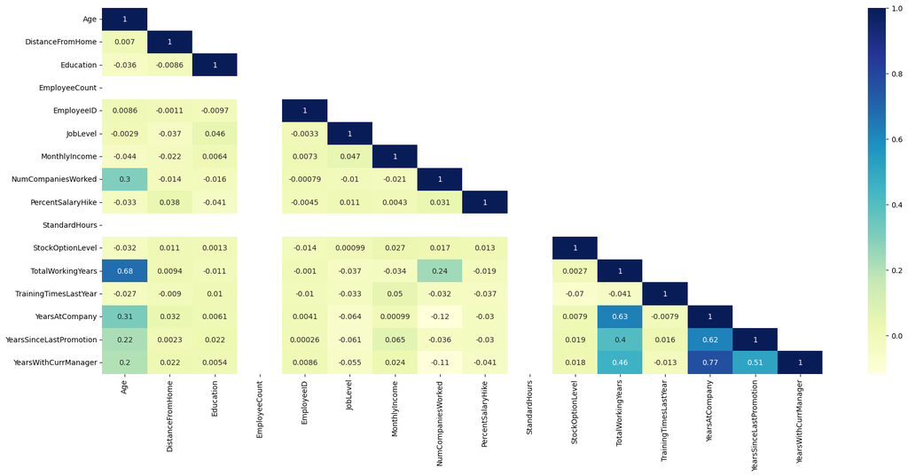

```python
plt.figure(figsize=(22,9))
corr_df = df.corr(method='pearson')
df_lt = corr_df.where(np.tril(np.ones(corr_df.shape)).astype(bool))
hmp = sns.heatmap(data=df_lt, cmap='YlGnBu', annot=True)
```

#### Insights

- No existe multicolinealidad, pero existen relaciones curiosas entre los campos, TotalWorkingYears - YearsAtCompany - YearsWithCurrManager

### Gráfico por Distribución

```python
numerics = ['int16', 'int32', 'int64', 'float64']
df.select_dtypes(include=numerics).sample(5)
```

|  | Age | DistanceFromHome | Education | EmployeeCount | EmployeeID | JobLevel | MonthlyIncome | NumCompaniesWorked | PercentSalaryHike | StandardHours | StockOptionLevel | TotalWorkingYears | TrainingTimesLastYear | YearsAtCompany | YearsSinceLastPromotion | YearsWithCurrManager |
| --- | --- | --- | --- | --- | --- | --- | --- | --- | --- | --- | --- | --- | --- | --- | --- | --- |
| 3062 | 24 | 1 | 3 | 1 | 3063 | 5 | 28970 | 1.0 | 18 | 8 | 3 | 5.0 | 4 | 5 | 0 | 3 |
| 2150 | 58 | 27 | 3 | 1 | 2151 | 2 | 21870 | 1.0 | 18 | 8 | 1 | 2.0 | 1 | 2 | 2 | 2 |
| 2889 | 36 | 1 | 3 | 1 | 2890 | 2 | 23050 | 1.0 | 17 | 8 | 0 | 8.0 | 3 | 8 | 1 | 7 |
| 2342 | 35 | 4 | 3 | 1 | 2343 | 2 | 74030 | 1.0 | 12 | 8 | 1 | 10.0 | 4 | 10 | 6 | 8 |
| 1455 | 40 | 2 | 3 | 1 | 1456 | 1 | 27180 | 1.0 | 14 | 8 | 1 | 9.0 | 4 | 9 | 4 | 7 |

```python
# Se seleccional as columnas de tipo numérico
cols_num = df.columns[[np.issubdtype(dt, np.number) for dt in df.dtypes]]
cols_num
```

```
Index(['Age', 'DistanceFromHome', 'Education', 'EmployeeCount', 'EmployeeID',
       'JobLevel', 'MonthlyIncome', 'NumCompaniesWorked', 'PercentSalaryHike',
       'StandardHours', 'StockOptionLevel', 'TotalWorkingYears',
       'TrainingTimesLastYear', 'YearsAtCompany', 'YearsSinceLastPromotion',
       'YearsWithCurrManager'],
      dtype='object')
```

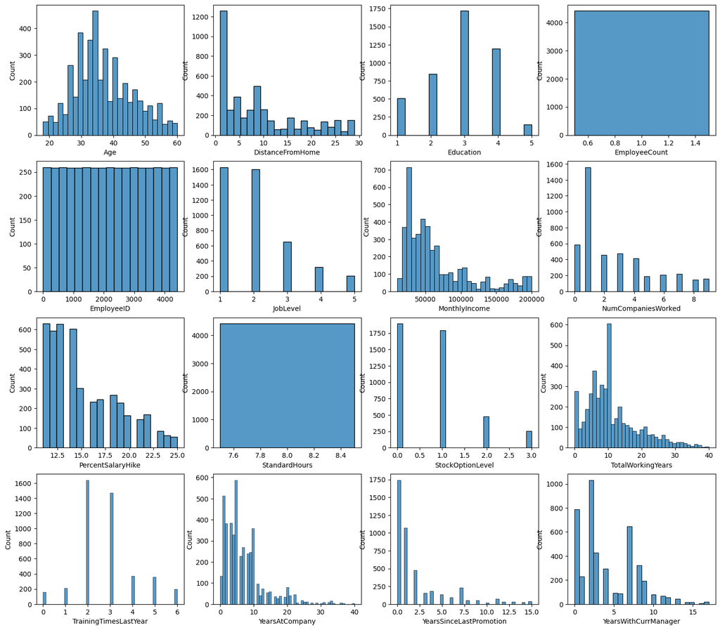

```python
# Gráfico exploratoria de todas las columnas numéricas (16 - cols_num)

fig, ax = plt.subplots(nrows=4, ncols=4, figsize=(18,16))
for i, column in enumerate(cols_num):
    sns.histplot(data=df, x=column, ax=ax[i//4, i%4], kde=False)
```

#### Insights

- Las columas YearsAtCompany, TotalWorkingYears, MonthlyIncome parecen estar sesgadas
- El rango de la variable MonthlyIncome se podría estandaizar (está en cientos de miles a comparación de otras que estan en decenas o unidades)
- Las columnas StandardHours, EmployeeId no aportan ningún valor al modelo, se pueden eliminar
- EmployeeCount siendo siempre uno seguramente es utilizado para hacer cuentas de empleados y no usar el EmployeeID u otros valores

## Análisis Bivriado

```python
df.groupby(['TrainingTimesLastYear']).mean().T
```

| TrainingTimesLastYear | 0 | 1 | 2 | 3 | 4 | 5 | 6 |
| --- | --- | --- | --- | --- | --- | --- | --- |
| Age | 37.222222 | 38.492958 | 37.208410 | 36.576375 | 36.528455 | 35.285714 | 38.938462 |
| DistanceFromHome | 9.833333 | 10.985915 | 8.804388 | 9.274949 | 9.471545 | 8.798319 | 9.538462 |
| Education | 2.796296 | 3.056338 | 2.839122 | 2.979633 | 3.024390 | 2.932773 | 2.723077 |
| EmployeeCount | 1.000000 | 1.000000 | 1.000000 | 1.000000 | 1.000000 | 1.000000 | 1.000000 |
| EmployeeID | 2183.611111 | 2309.929577 | 2205.654479 | 2200.089613 | 2235.268293 | 2162.705882 | 2171.200000 |
| JobLevel | 1.907407 | 2.042254 | 2.102377 | 2.112016 | 1.983740 | 1.991597 | 1.815385 |
| MonthlyIncome | 60866.666667 | 70142.394366 | 63903.071298 | 64080.040733 | 56839.024390 | 72949.915966 | 80548.615385 |
| NumCompaniesWorked | 3.425926 | 2.718310 | 2.630104 | 2.719620 | 2.940379 | 2.170868 | 2.846154 |
| PercentSalaryHike | 15.500000 | 15.408451 | 15.341865 | 15.002037 | 15.821138 | 14.873950 | 14.661538 |
| StandardHours | 8.000000 | 8.000000 | 8.000000 | 8.000000 | 8.000000 | 8.000000 | 8.000000 |
| StockOptionLevel | 0.981481 | 0.845070 | 0.842779 | 0.733198 | 0.886179 | 0.739496 | 0.553846 |
| TotalWorkingYears | 12.055556 | 11.760563 | 11.497867 | 11.272912 | 10.910569 | 9.596639 | 12.097436 |
| YearsAtCompany | 7.462963 | 7.492958 | 7.073126 | 6.828921 | 7.056911 | 6.016807 | 8.630769 |
| YearsSinceLastPromotion | 1.814815 | 2.323944 | 2.117002 | 2.264766 | 2.479675 | 1.714286 | 2.676923 |
| YearsWithCurrManager | 4.759259 | 4.507042 | 4.062157 | 4.079430 | 4.040650 | 3.831933 | 4.707692 |

```python
df.groupby(['JobLevel']).mean().T
```

| JobLevel | 1 | 2 | 3 | 4 | 5 |
| --- | --- | --- | --- | --- | --- |
| Age | 36.775322 | 37.367041 | 36.266055 | 36.377358 | 37.579710 |
| DistanceFromHome | 9.381215 | 9.415730 | 8.784404 | 8.273585 | 8.681159 |
| Education | 2.841621 | 2.945693 | 2.940367 | 3.047170 | 2.927536 |
| EmployeeCount | 1.000000 | 1.000000 | 1.000000 | 1.000000 | 1.000000 |
| EmployeeID | 2189.810313 | 2237.709738 | 2196.220183 | 2142.886792 | 2205.202899 |
| MonthlyIncome | 62677.421731 | 65506.479401 | 63545.321101 | 77940.754717 | 64698.405797 |
| NumCompaniesWorked | 2.669122 | 2.742821 | 2.772171 | 2.443396 | 2.603865 |
| PercentSalaryHike | 14.963168 | 15.475655 | 15.412844 | 14.783019 | 15.101449 |
| StandardHours | 8.000000 | 8.000000 | 8.000000 | 8.000000 | 8.000000 |
| StockOptionLevel | 0.823204 | 0.758427 | 0.793578 | 0.716981 | 0.956522 |
| TotalWorkingYears | 11.348066 | 11.647940 | 10.723242 | 10.990566 | 10.086957 |
| TrainingTimesLastYear | 2.882136 | 2.769663 | 2.651376 | 2.801887 | 2.840580 |
| YearsAtCompany | 7.338858 | 7.106742 | 6.426606 | 7.169811 | 5.231884 |
| YearsSinceLastPromotion | 2.418048 | 2.155431 | 1.876147 | 2.245283 | 1.521739 |
| YearsWithCurrManager | 4.384899 | 3.998127 | 3.926606 | 4.481132 | 3.101449 |

```python
df.groupby(['StockOptionLevel']).mean()[['Age', 'DistanceFromHome', 'MonthlyIncome', 'TotalWorkingYears']]
```

| StockOptionLevel | Age | DistanceFromHome | MonthlyIncome | TotalWorkingYears |
| --- | --- | --- | --- | --- |
| 0 | 36.939778 | 9.169572 | 63077.606973 | 11.159007 |
| 1 | 37.278523 | 9.156040 | 66549.630872 | 11.378076 |
| 2 | 36.354430 | 9.025316 | 66898.924051 | 11.810127 |
| 3 | 35.376471 | 9.929412 | 65382.470588 | 10.494118 |

## Feature Engineering

```python
# Genera una copia del df
df2 = df.copy()
```

```python
# ELIMINAR COLUMNAS NO NECESARIAS
df2.drop(columns=['EmployeeID', 'StandardHours', 'Over18', 'EmployeeCount'], inplace=True)
df2.sample(3)
```

|  | Age | Attrition | BusinessTravel | Department | DistanceFromHome | Education | EducationField | Gender | JobLevel | JobRole | MaritalStatus | MonthlyIncome | NumCompaniesWorked | PercentSalaryHike | StockOptionLevel | TotalWorkingYears | TrainingTimesLastYear | YearsAtCompany | YearsSinceLastPromotion | YearsWithCurrManager |
| --- | --- | --- | --- | --- | --- | --- | --- | --- | --- | --- | --- | --- | --- | --- | --- | --- | --- | --- | --- | --- |
| 722 | 31 | Yes | Travel_Frequently | Research & Development | 2 | 2 | Medical | Female | 2 | Manufacturing Director | Single | 53960 | 7.0 | 17 | 1 | 3.0 | 2 | 1 | 0 | 0 |
| 228 | 37 | No | Travel_Rarely | Sales | 9 | 4 | Marketing | Female | 2 | Laboratory Technician | Married | 20860 | 4.0 | 14 | 0 | 17.0 | 3 | 3 | 1 | 0 |
| 2949 | 25 | No | Non-Travel | Research & Development | 7 | 4 | Medical | Female | 4 | Laboratory Technician | Divorced | 134640 | 1.0 | 13 | 1 | 6.0 | 2 | 6 | 1 | 5 |

```python
# CAMBIAR COLUMNAS OBJECT POR CATEGORY
df2['BusinessTravel'] = df2['BusinessTravel'].astype('category')
df2['Department'] = df2['Department'].astype('category')
df2['EducationField'] = df2['EducationField'].astype('category')
df2['Gender'] = df2['Gender'].astype('category')

# Cambiar columnas NumCompaniesWorked a entero
df2['NumCompaniesWorked'] = df2['NumCompaniesWorked'].fillna(value=0).astype('int')
```

```python
df2.info()
```

```
<class 'pandas.core.frame.DataFrame'>
RangeIndex: 4410 entries, 0 to 4409
Data columns (total 20 columns):
 #   Column                   Non-Null Count  Dtype
---  ------                   --------------  -----
 0   Age                      4410 non-null   int64
 1   Attrition                4410 non-null   object
 2   BusinessTravel           4410 non-null   category
 3   Department               4410 non-null   category
 4   DistanceFromHome         4410 non-null   int64
 5   Education                4410 non-null   int64
 6   EducationField           4410 non-null   category
 7   Gender                   4410 non-null   category
 8   JobLevel                 4410 non-null   int64
 9   JobRole                  4410 non-null   object
 10  MaritalStatus            4410 non-null   object
 11  MonthlyIncome            4410 non-null   int64
 12  NumCompaniesWorked       4410 non-null   int32
 13  PercentSalaryHike        4410 non-null   int64
 14  StockOptionLevel         4410 non-null   int64
 15  TotalWorkingYears        4410 non-null   float64
 16  TrainingTimesLastYear    4410 non-null   int64
 17  YearsAtCompany           4410 non-null   int64
 18  YearsSinceLastPromotion  4410 non-null   int64
 19  YearsWithCurrManager     4410 non-null   int64
dtypes: category(4), float64(1), int32(1), int64(11), object(3)
memory usage: 552.0+ KB
```

### Balanceo de Clases

```python
# BALANCEO DE CLASES - PASAR LAS CLASES QUE TENGAN REPRESENTACIÓN EN MENOS DEL 5% DE LOS CASOS EN UNA CATEGORÍA DE OTHER
print(df2['EducationField'].value_counts(normalize=True),'\n')
print(df2['BusinessTravel'].value_counts(normalize=True), '\n')
print(df2['Department'].value_counts(normalize=True), '\n')
print(df2['MaritalStatus'].value_counts(normalize=True), '\n')
print(df2['JobRole'].value_counts(normalize=True), '\n')
print(df2['Gender'].value_counts(normalize=True), '\n')
```

```
Life Sciences       0.412245
Medical             0.315646
Marketing           0.108163
Technical Degree    0.089796
Other               0.055782
Human Resources     0.018367
Name: EducationField, dtype: float64

Travel_Rarely        0.709524
Travel_Frequently    0.188435
Non-Travel           0.102041
Name: BusinessTravel, dtype: float64

Research & Development    0.653741
Sales                     0.303401
Human Resources           0.042857
Name: Department, dtype: float64

Married     0.457823
Single      0.319728
Divorced    0.222449
Name: MaritalStatus, dtype: float64

Sales Executive              0.221769
Research Scientist           0.198639
Laboratory Technician        0.176190
Manufacturing Director       0.098639
Healthcare Representative    0.089116
Manager                      0.069388
Sales Representative         0.056463
Research Director            0.054422
Human Resources              0.035374
Name: JobRole, dtype: float64

Male      0.6
Female    0.4
Name: Gender, dtype: float64
```

```python
# EducationField - Agregar Human Resources a Other
df2['EducationField'] = df2['EducationField'].replace(to_replace={'Human Resources': 'Other'})
```

```python
print(df2['EducationField'].value_counts(normalize=True))
```

```
Life Sciences       0.412245
Medical             0.315646
Marketing           0.108163
Technical Degree    0.089796
Other               0.074150
Name: EducationField, dtype: float64
```

```python
# Cambio de tipo de columnas categóricas - Automático
# Se decidió utilizar variables dummy para BuisenessTravel, Department, EducationField, JobRole, MaritalStatus
# Para Gender y Attrition, se decidió utilizar reemplazar los valores por 1/0

df2['Gender'] = df2['Gender'].replace(to_replace={'Male':0, 'Female':1})
df2['Attrition'] = df2['Attrition'].replace(to_replace={'Yes':1, 'No':0})

df2 = pd.get_dummies(data=df2)

df2
```

|  | Age | Attrition | DistanceFromHome | Education | JobLevel | MonthlyIncome | NumCompaniesWorked | PercentSalaryHike | StockOptionLevel | TotalWorkingYears | ... | JobRole_Laboratory Technician | JobRole_Manager | JobRole_Manufacturing Director | JobRole_Research Director | JobRole_Research Scientist | JobRole_Sales Executive | JobRole_Sales Representative | MaritalStatus_Divorced | MaritalStatus_Married | MaritalStatus_Single |
| --- | --- | --- | --- | --- | --- | --- | --- | --- | --- | --- | --- | --- | --- | --- | --- | --- | --- | --- | --- | --- | --- |
| 0 | 51 | 0 | 6 | 2 | 1 | 131160 | 1 | 11 | 0 | 1.0 | ... | 0 | 0 | 0 | 0 | 0 | 0 | 0 | 0 | 1 | 0 |
| 1 | 31 | 1 | 10 | 1 | 1 | 41890 | 0 | 23 | 1 | 6.0 | ... | 0 | 0 | 0 | 0 | 1 | 0 | 0 | 0 | 0 | 1 |
| 2 | 32 | 0 | 17 | 4 | 4 | 193280 | 1 | 15 | 3 | 5.0 | ... | 0 | 0 | 0 | 0 | 0 | 1 | 0 | 0 | 1 | 0 |
| 3 | 38 | 0 | 2 | 5 | 3 | 83210 | 3 | 11 | 3 | 13.0 | ... | 0 | 0 | 0 | 0 | 0 | 0 | 0 | 0 | 1 | 0 |
| 4 | 32 | 0 | 10 | 1 | 1 | 23420 | 4 | 12 | 2 | 9.0 | ... | 0 | 0 | 0 | 0 | 0 | 1 | 0 | 0 | 0 | 1 |
| ... | ... | ... | ... | ... | ... | ... | ... | ... | ... | ... | ... | ... | ... | ... | ... | ... | ... | ... | ... | ... | ... |
| 4405 | 42 | 0 | 5 | 4 | 1 | 60290 | 3 | 17 | 1 | 10.0 | ... | 0 | 0 | 0 | 0 | 1 | 0 | 0 | 0 | 0 | 1 |
| 4406 | 29 | 0 | 2 | 4 | 1 | 26790 | 2 | 15 | 0 | 10.0 | ... | 1 | 0 | 0 | 0 | 0 | 0 | 0 | 1 | 0 | 0 |
| 4407 | 25 | 0 | 25 | 2 | 2 | 37020 | 0 | 20 | 0 | 5.0 | ... | 0 | 0 | 0 | 0 | 0 | 1 | 0 | 0 | 1 | 0 |
| 4408 | 42 | 0 | 18 | 2 | 1 | 23980 | 0 | 14 | 1 | 10.0 | ... | 1 | 0 | 0 | 0 | 0 | 0 | 0 | 1 | 0 | 0 |
| 4409 | 40 | 0 | 28 | 3 | 2 | 54680 | 0 | 12 | 0 | 11.0 | ... | 1 | 0 | 0 | 0 | 0 | 0 | 0 | 1 | 0 | 0 |

4410 rows × 39 columns

```python
# Estandarizar las columnas que lo necesiten (Income)
from sklearn.preprocessing import StandardScaler
scaler = StandardScaler()
df2['MonthlyIncome_scale'] = scaler.fit_transform(df2[['MonthlyIncome']])
df2.sample(3)
```

|  | Age | Attrition | DistanceFromHome | Education | JobLevel | MonthlyIncome | NumCompaniesWorked | PercentSalaryHike | StockOptionLevel | TotalWorkingYears | ... | JobRole_Manager | JobRole_Manufacturing Director | JobRole_Research Director | JobRole_Research Scientist | JobRole_Sales Executive | JobRole_Sales Representative | MaritalStatus_Divorced | MaritalStatus_Married | MaritalStatus_Single | MonthlyIncome_scale |
| --- | --- | --- | --- | --- | --- | --- | --- | --- | --- | --- | --- | --- | --- | --- | --- | --- | --- | --- | --- | --- | --- |
| 3151 | 32 | 1 | 7 | 2 | 2 | 32980 | 8 | 22 | 0 | 6.0 | ... | 0 | 0 | 1 | 0 | 0 | 0 | 0 | 1 | 0 | -0.680979 |
| 1242 | 33 | 0 | 3 | 3 | 1 | 43730 | 4 | 14 | 0 | 7.0 | ... | 0 | 1 | 0 | 0 | 0 | 0 | 0 | 0 | 1 | -0.452565 |
| 3879 | 20 | 0 | 1 | 3 | 1 | 47770 | 1 | 18 | 1 | 2.0 | ... | 0 | 0 | 0 | 0 | 0 | 1 | 0 | 0 | 1 | -0.366724 |

3 rows × 40 columns

```python
# Opcional - Eliminar la variable que se acaba de estandarizar
df2.drop(columns=['MonthlyIncome'], inplace=True)
```

## Data Split

```python
from sklearn.model_selection import train_test_split

x = df2.drop(columns=['Attrition'])
y = df2['Attrition']

# En este caso no es necesario, pero habría que convertir variables categóricas en dummy variables
x_train, x_test, y_train, y_test = train_test_split(x, y, test_size=.30, random_state=1)
```

## Regresión Logística

```python
print(df2['Attrition'].value_counts(normalize=True))
```

```
0    0.838776
1    0.161224
Name: Attrition, dtype: float64
```

Como se puede ver, en el dataset hay una pequeña cantidad de respuestas posivitas a comparación de la cantidad de respuestas negativas

https://www.analyticsvidhya.com/blog/2020/10/improve-class-imbalance-class-weights/

https://machinelearningmastery.com/cost-sensitive-logistic-regression/

```python
from sklearn.linear_model import LogisticRegression

# Creación del modelo
model = LogisticRegression(solver='liblinear')

# Entrenamiento del modelo
model.fit(x_train, y_train)

# Hacer predicción en con x_test
y_predict = model.predict(x_test)
```

```python
# Build a dataset with original and predicted
z = pd.DataFrame()
z['Attrition real'] = y_test
z['Attrition prediction'] = y_predict
z.sample(20)
```

|  | Attrition real | Attrition prediction |
| --- | --- | --- |
| 453 | 1 | 1 |
| 2639 | 0 | 0 |
| 1918 | 1 | 0 |
| 1501 | 0 | 0 |
| 3661 | 0 | 0 |
| 203 | 0 | 0 |
| 1409 | 0 | 0 |
| 4069 | 0 | 0 |
| 2273 | 0 | 0 |
| 1453 | 0 | 0 |
| 28 | 1 | 0 |
| 1296 | 0 | 0 |
| 3213 | 0 | 0 |
| 2010 | 1 | 0 |
| 4195 | 0 | 0 |
| 1377 | 0 | 0 |
| 357 | 0 | 0 |
| 3987 | 0 | 0 |
| 1232 | 0 | 0 |
| 2611 | 0 | 0 |

```python
# Tenera los coeficientes de la ecuación
coef_df = pd.DataFrame(model.coef_)
coef_df.columns = x.columns

# Incluir el intercept
coef_df['Intercept'] = model.intercept_
coef_df.T
```

|  | 0 |
| --- | --- |
| Age | -0.030033 |
| DistanceFromHome | -0.000333 |
| Education | -0.041780 |
| JobLevel | -0.033312 |
| NumCompaniesWorked | 0.132107 |
| PercentSalaryHike | 0.022312 |
| StockOptionLevel | -0.076700 |
| TotalWorkingYears | -0.065211 |
| TrainingTimesLastYear | -0.129351 |
| YearsAtCompany | 0.027393 |
| YearsSinceLastPromotion | 0.117369 |
| YearsWithCurrManager | -0.148730 |
| BusinessTravel_Non-Travel | -0.686801 |
| BusinessTravel_Travel_Frequently | 0.684039 |
| BusinessTravel_Travel_Rarely | -0.020373 |
| Department_Human Resources | 0.579358 |
| Department_Research & Development | -0.228419 |
| Department_Sales | -0.374075 |
| EducationField_Life Sciences | 0.110802 |
| EducationField_Marketing | -0.135779 |
| EducationField_Medical | 0.072018 |
| EducationField_Other | 0.035621 |
| EducationField_Technical Degree | -0.105799 |
| Gender_1 | -0.071894 |
| Gender_0 | 0.048759 |
| JobRole_Healthcare Representative | -0.024558 |
| JobRole_Human Resources | -0.408602 |
| JobRole_Laboratory Technician | 0.232202 |
| JobRole_Manager | -0.288983 |
| JobRole_Manufacturing Director | -0.470102 |
| JobRole_Research Director | 0.457353 |
| JobRole_Research Scientist | 0.227239 |
| JobRole_Sales Executive | 0.226191 |
| JobRole_Sales Representative | 0.026123 |
| MaritalStatus_Divorced | -0.406031 |
| MaritalStatus_Married | -0.255328 |
| MaritalStatus_Single | 0.638224 |
| MonthlyIncome_scale | -0.034717 |
| Intercept | -0.023135 |

```python
print(df['JobRole'].value_counts())
```

```
Sales Executive              978
Research Scientist           876
Laboratory Technician        777
Manufacturing Director       435
Healthcare Representative    393
Manager                      306
Sales Representative         249
Research Director            240
Human Resources              156
Name: JobRole, dtype: int64
```

### Matriz de confusión

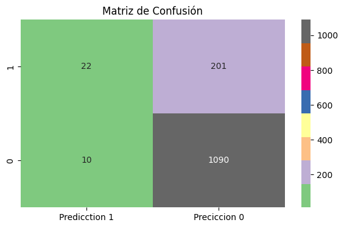

```python
from sklearn import metrics

cm = metrics.confusion_matrix(y_test, y_predict, labels=[1,0])

df_cm = pd.DataFrame(cm, index=[i for i in ['1', '0']],
                     columns=[i for i in ['Predicction 1', 'Preciccion 0']])

plt.figure(figsize=(7,4))
sns.heatmap(df_cm, annot=True, cmap='Accent', fmt='d').set_title('Matriz de Confusión')
```

```python
# Medidas del modelo
from sklearn.metrics import accuracy_score, f1_score, precision_score, recall_score, roc_auc_score, classification_report, confusion_matrix

model_score = accuracy_score(y_test, y_predict)
recall_score = recall_score(y_test, y_predict)
precision_score = precision_score(y_test, y_predict)
f1_score = f1_score(y_test, y_predict)

print('Medidas del modelo')
print('----------------------')
print('Accuracy = {0:0.2f}'.format(model_score))
print('Precision = {0:0.2f}'.format(precision_score))
print('Recall = {0:0.2f}'.format(recall_score))
print('F1 Score = {0:0.2f}'.format(f1_score))
print('Accuracy = {0:0.2f}'.format(roc_auc_score(y_test, y_predict)))
```

```
Medidas del modelo
----------------------
Accuracy = 0.84
Precision = 0.69
Recall = 0.10
F1 Score = 0.17
Accuracy = 0.54
```